# Machine Learning II

## Random forests

21. Now you’re getting the hang of it! Instead of regression, let’s try a totally different model….random forests! Repeat all of your steps to see how well random forests do in predicting the `boston_test` data.

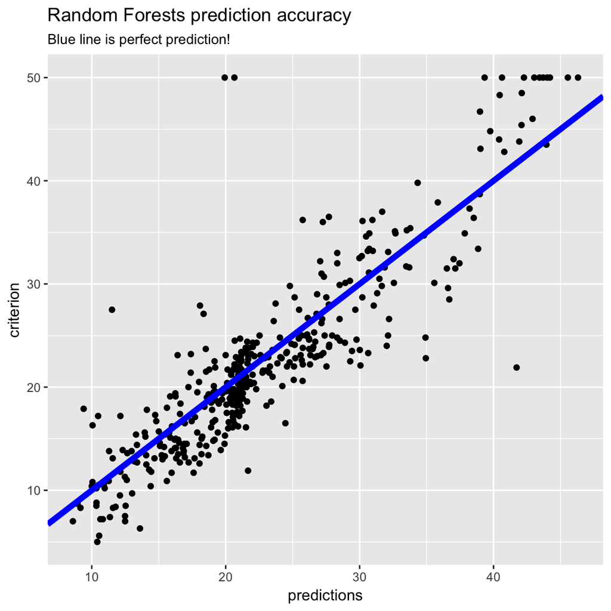

```r
boston_rf_train <- caret::train(form = medv ~ .,
                                   data = boston_train,
                                   method = "rf",
                                   trControl = rep10_control)

# VarImp() doesn't work for rf regression
# caret::varImp(boston_rf_train)

boston_rf_predictions <- predict(boston_rf_train,
                                 newdata = boston_test)

# Combine predictions and criterion in one tibble
performance_data <- tibble(predictions = boston_rf_predictions,
                          criterion = boston_test$medv)

# Plot results
ggplot(data = performance_data,
       aes(x = predictions, y = criterion)) +
  geom_point() +   # Add points
  geom_abline(slope = 1, intercept = 0, col = "blue", size = 2) +
  labs(title = "Random Forests prediction accuracy",
       subtitle = "Blue line is perfect prediction!")
```

```r
 postResample(pred = boston_rf_predictions,
              obs = boston_test$medv)
```

```
     RMSE  Rsquared       MAE
4.2500196 0.7846074 2.9331980
```

# heartdisease - Predicting heartdisease status

Now it’s time to try a classification problem. We’ll do this with the `heartdisease` data. The `heartdisease` dataset contains data from 303 patients suspected of having heart disease The objective is to predict the `diagnosis` column indicating whether a patient has heartdisease or not

Here is a description of each of the variables in the dataset

| Column | Description |
| --- | --- |
| age | Age |
| sex | Sex, 1 = male, 0 = female |
| cp | Chest pain type: ta = typical angina, aa = atypical angina, np = non-anginal pain, a = asymptomatic |
| trestbps | Resting blood pressure (in mm Hg on admission to the hospital) |
| chol | Serum cholestoral in mg/dl |
| fbs | Fasting blood sugar > 120 mg/dl: 1 = true, 0 = false |
| restecg | Resting electrocardiographic results. “normal” = normal, “abnormal” = having ST-T wave abnormality (T wave inversions and/or ST elevation or depression of > 0.05 mV), “hypertrophy” = showing probable … |
| thalach | Maximum heart rate achieved |
| exang | Exercise induced angina: 1 = yes, 0 = no |
| oldpeak | ST depression induced by exercise relative to rest |
| slope | The slope of the peak exercise ST segment. |
| ca | Number of major vessels (0-3) colored by flourosopy |
| thal | “normal” = normal, “fd” = fixed defect, “rd” = reversible defect |
| diagnosis | 1 = Heart disease, 0 = No Heart disease |

22. Load the training data `heartdisease_train.csv` into R as a new object with the name `heartdisease_train` using `read_csv()`.

```r
heartdisease_train <- read_csv("data/heartdisease_train.csv")
```

23. Before you do anything else, convert the `diagnosis` column to a factor. This will be necessary for some machine learning models to work!

```r
# Convert diagnosis to a factor
#   This is important for some machine learning models to do
#   classification analyses

heartdisease_train <- heartdisease_train %>%
  mutate(diagnosis = factor(diagnosis))      # Convert diagnosis to a factor
```

23. Follow tasks 2 - 5 to explore the data. Remember our goal is to predict `diagnosis`!

```r
heartdisease_train
```

```
# A tibble: 100 x 14
     age   sex cp    trestbps  chol   fbs restecg    thalach exang oldpeak
   <int> <int> <chr>    <int> <int> <int> <chr>        <int> <int>   <dbl>
 1    54     0 np         160   201     0 normal         163     0   0.
 2    54     0 np         135   304     1 normal         170     0   0.
 3    34     0 aa         118   210     0 normal         192     0   0.700
 4    57     1 a          152   274     0 normal          88     1   1.20
 5    60     0 a          150   258     0 hypertrop…     157     0   2.60
 6    56     1 a          125   249     1 hypertrop…     144     1   1.20
 7    63     1 a          130   254     0 hypertrop…     147     0   1.40
 8    64     1 np         125   309     0 normal         131     1   1.80
 9    58     0 a          170   225     1 hypertrop…     146     1   2.80
10    63     1 ta         145   233     1 hypertrop…     150     0   2.30
# ... with 90 more rows, and 4 more variables: slope <chr>, ca <int>,
#   thal <chr>, diagnosis <fct>
```

```r
mlr::summarizeColumns(heartdisease_train)
```

```
        name      type na    mean       disp median      mad min   max
1        age   integer  0  54.340  9.0299390  56.50  9.63690  34  77.0
2        sex   integer  0   0.720  0.4512609   1.00  0.00000   0   1.0
3         cp character  0      NA  0.4900000     NA       NA  10  51.0
4   trestbps   integer  0 133.100 16.2552245 130.00 14.82600 100 178.0
5       chol   integer  0 235.840 42.1099379 233.00 42.99540 149 340.0
6        fbs   integer  0   0.150  0.3588703   0.00  0.00000   0   1.0
7    restecg character  0      NA  0.4800000     NA       NA   1  52.0
8    thalach   integer  0 149.250 22.1880735 151.50 25.94550  88 194.0
9      exang   integer  0   0.410  0.4943111   0.00  0.00000   0   1.0
10   oldpeak   numeric  0   1.064  1.1966722   0.65  0.96369   0   4.2
11     slope character  0      NA  0.5200000     NA       NA   7  48.0
12        ca   integer  0   0.760  0.9547330   0.00  0.00000   0   3.0
13      thal character  0      NA  0.4500000     NA       NA   8  55.0
14 diagnosis    factor  0      NA  0.4500000     NA       NA  45  55.0
   nlevs
1      0
2      0
3      4
4      0
5      0
6      0
7      3
8      0
9      0
10     0
11     3
12     0
13     3
14     2
```

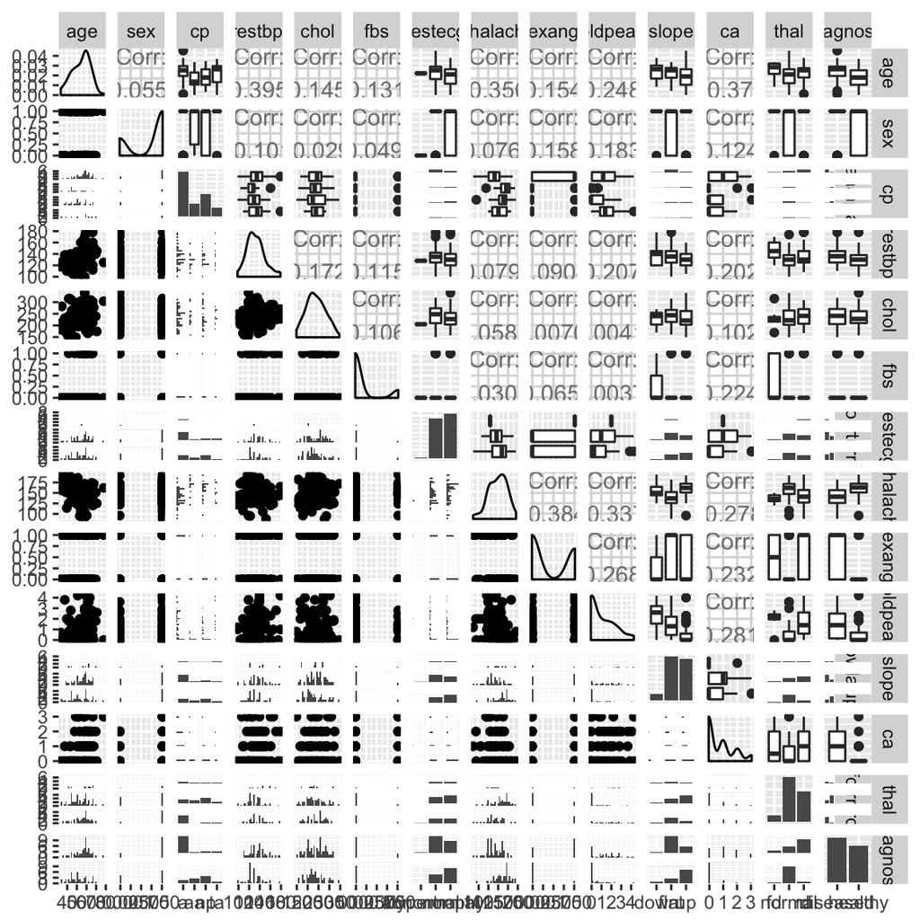

```r
ggpairs(heartdisease_train)
```

24. Now it’s time to train a model on the data. For this data, we can’t use linear regression because the criterion is a nominal class. Instead, we’ll start with a type of decision tree called CART. Look at http://topepo.github.io/caret/available-models.html to find the correct method for using CART.

```r
heartdisease_test <- read_csv("data/heartdisease_test.csv")

heartdisease_rpart_train <- caret::train(form = diagnosis ~ .,
                                        data = heartdisease_train,
                                        method = "rpart",
                                        trControl = rep10_control)

heartdisease_rpart_predictions <- predict(heartdisease_rpart_train,
                                          newdata = heartdisease_test)
```

25. Follow tasks 6 - 17 to fit your model, and evaluate its performance.
    - When you read in the `heartdisease_test` data, make sure to convert the `diagnosis` column to a factor like you did for the `heartdisease_train` data.
    - In task 14, where you try to visualise the performance of the model, you’ll need to tweak the plotting code a bit. To help, try using the following code template:

```r
# -----------------------------------------------------------
# Visualise the relationship between two nominal variables
# -----------------------------------------------------------

# Combine predictions and criterion in one tibble
performance_data <- tibble(predictions = heartdisease_rpart_predictions,
                          criterion = heartdisease_test$diagnosis)

# Plot results
ggplot(data = performance_data,
       aes(x = predictions, ..count..)) +
  geom_bar(aes(fill = criterion), position = "dodge") +
  labs(title = "CART prediction accuracy")

postResample(pred = heartdisease_rpart_predictions,
             obs = factor(heartdisease_test$diagnosis))
```

26. Now that you’ve fit CART, try using random forests! How well do random forests compare to plain old decision trees with CART?

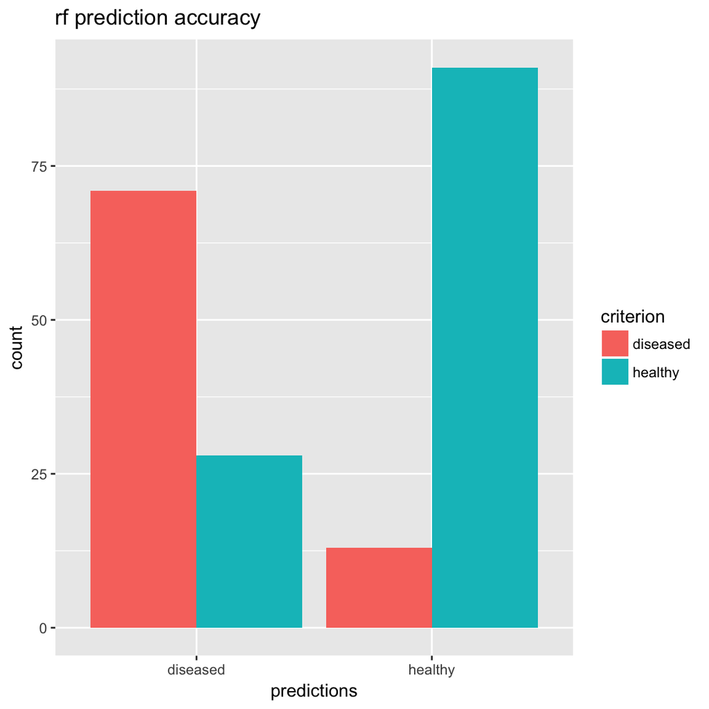

```r
heartdisease_rf_train <- caret::train(form = diagnosis ~ .,
                                        data = heartdisease_train,
                                        method = "rf",
                                        trControl = rep10_control)

heartdisease_rf_predictions <- predict(heartdisease_rf_train,
                                          newdata = heartdisease_test)


# Combine predictions and criterion in one tibble
performance_data <- tibble(predictions = heartdisease_rf_predictions,
                          criterion = heartdisease_test$diagnosis)

# Plot results
ggplot(data = performance_data,
       aes(x = predictions, ..count..)) +
  geom_bar(aes(fill = criterion), position = "dodge") +
  labs(title = "rf prediction accuracy")
```

```r
postResample(pred = heartdisease_rf_predictions,
             obs = factor(heartdisease_test$diagnosis))
```

```
 Accuracy     Kappa
0.7980296 0.5943364
```

27. If you’ve gotten this far, then you’ve really gotten the hang of the package! Try exploring the list of all models available in `caret` (again check out http://topepo.github.io/caret/available-models.html to see them all). Look for the craziest looking models you can find, and see how well they do on the two datasets in this practical. Can you find one that does much better than regression, random forests, or decision trees?

### Further Reading

- Max Kuhn, the author of `caret` has a fantastic overview of the package at http://topepo.github.io/caret/index.html. If you like the `caret` package as much as we do, be sure to go through this page in detail.
- Max Kuhn is also the co-author of a fantastic book on machine learning called [Applied predictive modelling - http://appliedpredictivemodeling.com/](http://appliedpredictivemodeling.com/).